# Analysing and Visualising the Dataset of OFDb about Super8 Italian Films

In this notebook I would like to analyse a dataset that comes from the OFDb.de Website, a community supported website that also features several Super8/16mm versions of films. Most of the small gauge versions from Germany are actually Super8 Version as it is demonstrated by the Company which were the actual distributors such as Marketing, UFA Büscher Film and Piccolo Film. This dataset contains thus a list of exclusively italian film productions and few italian co-productions that were distributed by UFA-Buscher Film, Piccolo Film and Marketing Film in Germany in the seventies and early eighties. These companies specialised in the distribution of "reduction prints" (reduced versions of films to be watched at home) on Super8-mm film material and had a specific library of film genres. In my analysis I want to give a glimpse in form of a "distant reading" of the film library, the most represented genres, directors, country of origins and original language of the distributions, in order to understand what was popular among reduction prints buyers.

The Dataset has been enriched with additional data through the software Open Refine. To the original Title of the films I added and reconciled the original title (the Ufa title was usually different than the original copy because reduction prints were often edited and shortened versions). From the original title I could add other fields as columns: director, original language, genre (limited to only 1 item), IMDb ID, year of production and country of origin.

To proceed to further analyse and later visualize my dataset I download the packages for python:

```python
#download the packages for doing an and visualizations

import numpy as np
import pandas as pd
import matplotlib.pyplot as plt
```

```python
#reading dataset with pandas, overview of the table content
italofilm_df = pd.read_csv('Italian_films_super8.csv',na_values=[0], delimiter=",")
```

### First let just take a look at the fields on the head of my dataset

Which columns are there? how many rows does the dataset have?

```python
italofilm_df.head() #first look at the dataset
```

|  | Title | Title_german_version | Year | director | Production_country | Co_production_country | Italian_coproduction | Co_production_country_2 | Co_production_country_3 | Original_language | Original_language_2 | genre | IMDb_ID |
| --- | --- | --- | --- | --- | --- | --- | --- | --- | --- | --- | --- | --- | --- |
| 0 | Long Live Your Death | Zwei wilde Companeros | 1971 | Duccio Tessari | Italy | Spain | National Production | Germany | NaN | Italian | NaN | western | tt0067303 |
| 1 | Odds and Evens | Zwei sind nicht zu bremsen | 1978 | Sergio Corbucci | Italy | United States of America | National Production | NaN | NaN | Italian | NaN | comedy | tt0078058 |
| 2 | Two Missionaries | Zwei Missionare | 1974 | Franco Rossi | Italy | France | National Production | NaN | NaN | Italian | NaN | adventure/action | tt0072012 |
| 3 | Crime Busters | Zwei außer Rand und Band | 1977 | Enzo Barboni | Italy | NaN | National Production | NaN | NaN | Italian | NaN | comedy | tt0074442 |
| 4 | Zombie Holocaust | Zombies unter Kannibalen | 1980 | Marino Girolami | Italy | NaN | National Production | NaN | NaN | Italian | English | horror | tt0079788 |

```python
#counting rows

rows_number = len(italofilm_df.index)
print("The dataset has " + str(rows_number) + " rows")
```

```
The dataset has 133 rows
```

Now I want to know which datatypes are in my dataset.

```python
#which data types I have
display(italofilm_df.dtypes)
```

```
Title                      object
Title_german_version       object
Year                        int64
director                   object
Production_country         object
Co_production_country      object
Italian_coproduction       object
Co_production_country_2    object
Co_production_country_3    object
Original_language          object
Original_language_2        object
genre                      object
IMDb_ID                    object
dtype: object
```

Let's see also what is in my dataset. As you may see many statistical values cannot be counted since most of data entries in my datasets are strings.

```python
italofilm_df.describe(include='all')
```

|  | Title | Title_german_version | Year | director | Production_country | Co_production_country | Italian_coproduction | Co_production_country_2 | Co_production_country_3 | Original_language | Original_language_2 | genre | IMDb_ID |
| --- | --- | --- | --- | --- | --- | --- | --- | --- | --- | --- | --- | --- | --- |
| count | 133 | 133 | 133.000000 | 133 | 133 | 82 | 133 | 27 | 6 | 130 | 12 | 133 | 133 |
| unique | 132 | 133 | NaN | 92 | 8 | 7 | 2 | 7 | 6 | 5 | 3 | 15 | 132 |
| top | Merveilleuse Angélique | Zwei wilde Companeros | NaN | Sergio Corbucci | Italy | Spain | National Production | Germany | Italy | Italian | English | western | tt0058343 |
| freq | 2 | 1 | NaN | 6 | 105 | 23 | 105 | 12 | 1 | 94 | 7 | 43 | 2 |
| mean | NaN | NaN | 1970.112782 | NaN | NaN | NaN | NaN | NaN | NaN | NaN | NaN | NaN | NaN |
| std | NaN | NaN | 5.685780 | NaN | NaN | NaN | NaN | NaN | NaN | NaN | NaN | NaN | NaN |
| min | NaN | NaN | 1952.000000 | NaN | NaN | NaN | NaN | NaN | NaN | NaN | NaN | NaN | NaN |
| 25% | NaN | NaN | 1967.000000 | NaN | NaN | NaN | NaN | NaN | NaN | NaN | NaN | NaN | NaN |
| 50% | NaN | NaN | 1969.000000 | NaN | NaN | NaN | NaN | NaN | NaN | NaN | NaN | NaN | NaN |
| 75% | NaN | NaN | 1974.000000 | NaN | NaN | NaN | NaN | NaN | NaN | NaN | NaN | NaN | NaN |
| max | NaN | NaN | 1981.000000 | NaN | NaN | NaN | NaN | NaN | NaN | NaN | NaN | NaN | NaN |

How many films are in my dataset that have been produced in a certain year? To reply to this question I will first I import Seaborn for displaying the charts, second I have to count some of the values frequency since my data entries are often just strings.

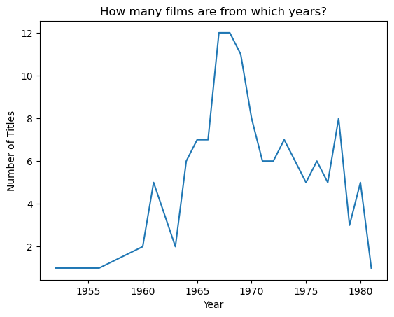

```python
#Line chart of films per year of production
#import Seaborn

#dataframe['Column'].value_counts()

import matplotlib.pyplot as plt

import seaborn as sns

# Lineplot: wrong kind of plot, data not continuous but categorical
#count of Titles

counts=italofilm_df['Year'].value_counts() #counting values for year

#print(counts)
sns.lineplot(x=counts.index,y=counts.values) #using lineplot

# set color palette
sns.color_palette("tab20")

# Titel und Labels
plt.title('How many films are from which years?')
plt.xlabel('Year')
plt.ylabel('Number of Titles')

plt.show()
```

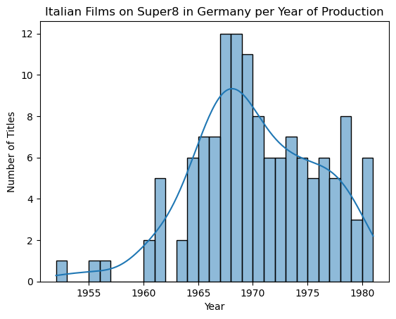

```python
#histogram of titles per year

sns.histplot(italofilm_df["Year"], binwidth=1, kde=True)

# Titel und Labels
plt.title('Italian Films on Super8 in Germany per Year of Production')
sns.color_palette("tab20c")
plt.xlabel('Year')
plt.ylabel('Number of Titles')
plt.savefig("Italofilm_jpg")


plt.show()
```

Now I want to visualize the frequency of certain genres within my film dataset. First I need to count how many times certain genres (as strings) are showing in my dataset

```python
#Titles per year genres


# Get count duplicates single column using dataframe.pivot_table()
genres_df = italofilm_df.pivot_table(index = ['genre'], aggfunc ='size')
print(genres_df)
```

```
genre
adventure/action     16
biographical film     1
cannibal film         1
comedy               24
crime/thriller        6
documentary           1
drama                 8
fantasy               2
horror               20
nun-sploitation       1
rom-com               3
sci-fi                2
sexploitation         1
spy film              4
western              43
dtype: int64
```

Looking at other people work on film lists I also want to show only the most frequent genres and group those that are coming less often into a single group in order to visualize it better in a chart. I took part of the code from github page of CamPaiva.

```python
#counting the frequency of genres per film

genre_list = pd.DataFrame(italofilm_df.genre.value_counts())
genre_list["Frequency"] = italofilm_df.genre.value_counts(normalize=True)
genre_list = genre_list.reset_index()
genre_list = genre_list.rename(columns = {"index": "genre", "count": "Number of Films"})
genre_list.loc[genre_list.Frequency < 0.03, 'genre'] = 'Others'
genre_list = (genre_list
                .groupby('genre').sum()
                .sort_values('Number of Films', ascending=False)
                .reset_index())
print(genre_list)
```

```
              genre  Number of Films  Frequency
0           western               43   0.323308
1            comedy               24   0.180451
2            horror               20   0.150376
3  adventure/action               16   0.120301
4            Others               12   0.090226
5             drama                8   0.060150
6    crime/thriller                6   0.045113
7          spy film                4   0.030075
```

Now with the genre_list I can create another histogram of the most frequent genres.

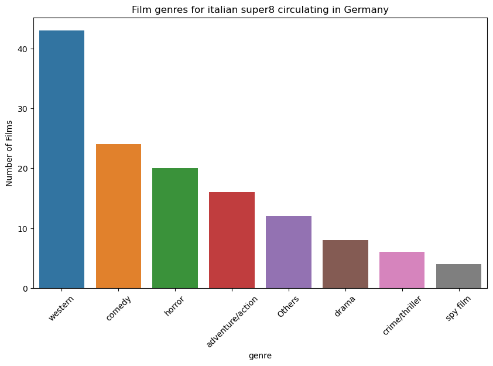

```python
#histogram from genre_list

plt.figure(figsize=(10, 6))
sns.barplot(data=genre_list, x="genre", y="Number of Films")
sns.color_palette("tab20")
plt.title("Film genres for italian super8 circulating in Germany")
plt.savefig("Italofilm_genres.jpg", dpi=300)
plt.xticks(rotation = 45)
plt.show()
```

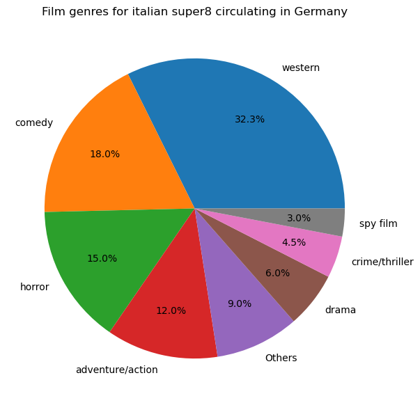

```python
#pie chart
plt.figure(figsize=(9, 7))
plt.pie(genre_list["Number of Films"], labels = genre_list["genre"], autopct='%1.1f%%', pctdistance=0.7)
sns.color_palette("tab20")
plt.title("Film genres for italian super8 circulating in Germany")
plt.savefig("Italofilm_Genres_Pie.jpg", dpi=250, bbox_inches='tight')
```

## And who are the most represented directors?

```python
director_list = pd.DataFrame(italofilm_df.director.value_counts())
director_list["Frequency"] = italofilm_df.director.value_counts(normalize=True)
director_list = director_list.reset_index()
director_list = director_list.rename(columns = {"index": "director", "count": "Number of Films"})
director_list.loc[director_list.Frequency < 0.02, 'director'] = 'Others'
director_list=(director_list
               .groupby('director').sum()
               .sort_values('Number of Films', ascending=False)
               .reset_index)
print(director_list)
```

```
<bound method DataFrame.reset_index of                    Number of Films  Frequency
director
Others                          94   0.706767
Sergio Corbucci                  6   0.045113
Harald Reinl                     4   0.030075
Joe D'Amato                      4   0.030075
Lucio Fulci                      4   0.030075
Bernard Borderie                 3   0.022556
Enzo Barboni                     3   0.022556
Giuliano Carnimeo                3   0.022556
Jesús Franco                     3   0.022556
Sergio Leone                     3   0.022556
Sergio Martino                   3   0.022556
Tonino Valerii                   3   0.022556>
```

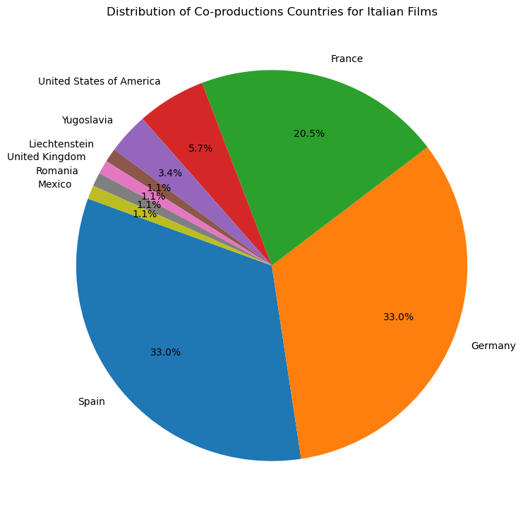

```python
# Combine values from the specified columns into a single column
country_columns = ['Co_production_country', 'Co_production_country_2', 'Co_production_country_3']
combined_countries = italofilm_df[country_columns].stack().reset_index(drop=True)

# Replace "West Germany" with "Germany"
combined_countries = combined_countries.replace('West Germany', 'Germany')


# Exclude the specific country (e.g., Italy)
excluded_country = 'Italy'
combined_countries = combined_countries[combined_countries != excluded_country]

# Count the occurrences of each country
country_counts = combined_countries.value_counts()

# Plot a pie chart
plt.figure(figsize=(9, 9))
plt.pie(country_counts, labels=country_counts.index, autopct='%1.1f%%', pctdistance=0.7, startangle=160)
plt.title('Distribution of Co-productions Countries for Italian Films')
plt.show()

plt.savefig("Italofilm_Co_production_Pie.jpg")
```

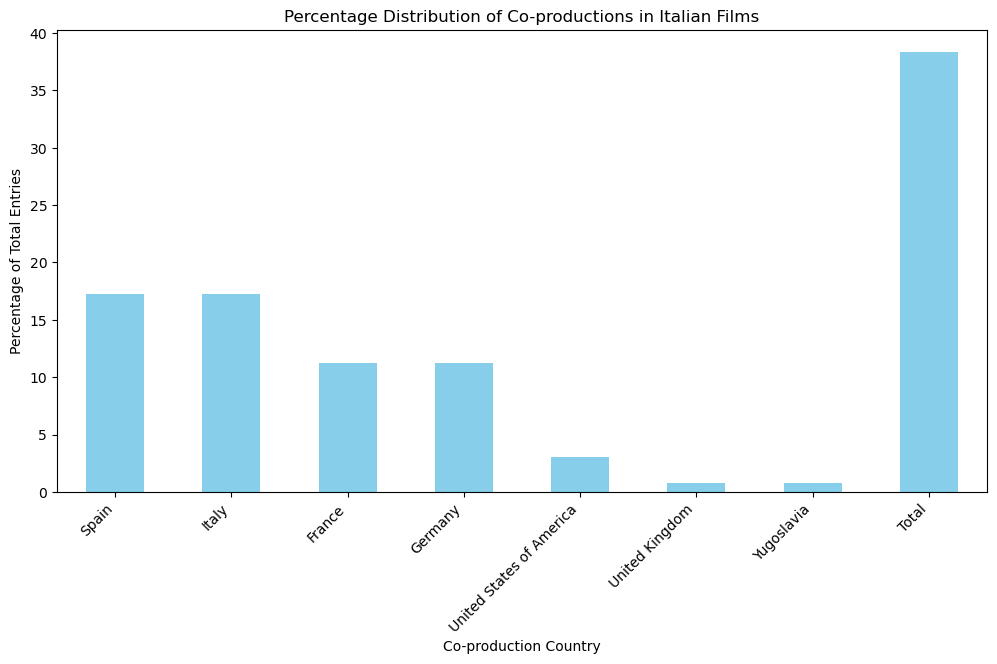

```python
# Count the occurrences of each country in the 'Co_production_country' column
co_production_counts = italofilm_df['Co_production_country'].value_counts()

# Calculate the percentage distribution
co_production_percentages = (co_production_counts / len(italofilm_df)) * 100

# Create a "Total" category by subtracting the sum of individual countries from 100%
co_production_percentages['Total'] = 100 - co_production_percentages.sum()

# Plot a bar chart
plt.figure(figsize=(12, 6))
co_production_percentages.plot(kind='bar', color='skyblue')
plt.title('Percentage Distribution of Co-productions in Italian Films')
plt.xlabel('Co-production Country')
plt.ylabel('Percentage of Total Entries')
plt.xticks(rotation=45, ha='right')  # Rotate x-axis labels for better readability
plt.show()
```

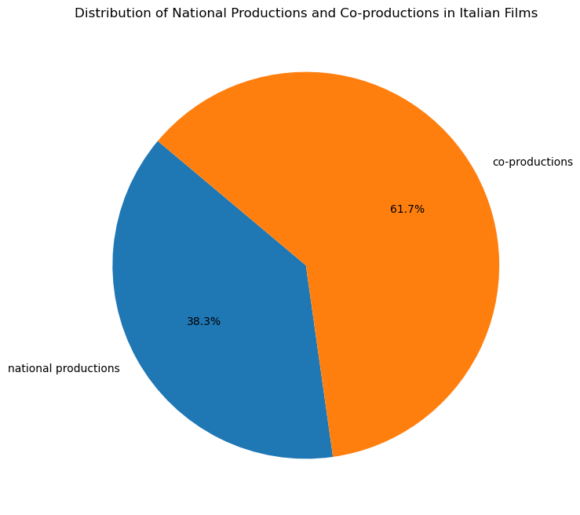

```python
# Count the occurrences of each value in the 'Co_production_country' column
co_production_counts = italofilm_df['Co_production_country'].value_counts()

# Calculate the percentage distribution
co_production_percentages = (co_production_counts / len(italofilm_df)) * 100

# Create a "national productions" category by subtracting the sum of individual countries from 100%
co_production_percentages['national productions'] = 100 - co_production_percentages.sum()

# Sum all individual country percentages for the "co-productions" category
co_productions_percentage = co_production_percentages.drop('national productions').sum()

# Create a DataFrame for the pie chart
pie_data = pd.Series({'national productions': co_production_percentages['national productions'],
                     'co-productions': co_productions_percentage})

# Plot a pie chart
plt.figure(figsize=(8, 8))
pie_data.plot(kind='pie', autopct='%1.1f%%', startangle=140)
plt.title('Distribution of National Productions and Co-productions in Italian Films')
plt.ylabel('')
plt.show()
```